# White Wine Quality Analysis by Vijayasarathi

[output not shown]

## Data Loading…

Summary of the Data Set

```
##   X fixed.acidity volatile.acidity citric.acid residual.sugar chlorides
## 1 1           7.0             0.27        0.36           20.7     0.045
## 2 2           6.3             0.30        0.34            1.6     0.049
## 3 3           8.1             0.28        0.40            6.9     0.050
## 4 4           7.2             0.23        0.32            8.5     0.058
## 5 5           7.2             0.23        0.32            8.5     0.058
## 6 6           8.1             0.28        0.40            6.9     0.050
##   free.sulfur.dioxide total.sulfur.dioxide density   pH sulphates alcohol
## 1                  45                  170  1.0010 3.00      0.45     8.8
## 2                  14                  132  0.9940 3.30      0.49     9.5
## 3                  30                   97  0.9951 3.26      0.44    10.1
## 4                  47                  186  0.9956 3.19      0.40     9.9
## 5                  47                  186  0.9956 3.19      0.40     9.9
## 6                  30                   97  0.9951 3.26      0.44    10.1
##   quality
## 1       6
## 2       6
## 3       6
## 4       6
## 5       6
## 6       6
```

```
##         X fixed.acidity volatile.acidity citric.acid residual.sugar
## 4893 4893           6.5             0.23        0.38            1.3
## 4894 4894           6.2             0.21        0.29            1.6
## 4895 4895           6.6             0.32        0.36            8.0
## 4896 4896           6.5             0.24        0.19            1.2
## 4897 4897           5.5             0.29        0.30            1.1
## 4898 4898           6.0             0.21        0.38            0.8
##      chlorides free.sulfur.dioxide total.sulfur.dioxide density   pH
## 4893     0.032                  29                  112 0.99298 3.29
## 4894     0.039                  24                   92 0.99114 3.27
## 4895     0.047                  57                  168 0.99490 3.15
## 4896     0.041                  30                  111 0.99254 2.99
## 4897     0.022                  20                  110 0.98869 3.34
## 4898     0.020                  22                   98 0.98941 3.26
##      sulphates alcohol quality
## 4893      0.54     9.7       5
## 4894      0.50    11.2       6
## 4895      0.46     9.6       5
## 4896      0.46     9.4       6
## 4897      0.38    12.8       7
## 4898      0.32    11.8       6
```

```
##        X        fixed.acidity    volatile.acidity  citric.acid
##  Min.   :   1   Min.   : 3.800   Min.   :0.0800   Min.   :0.0000
##  1st Qu.:1225   1st Qu.: 6.300   1st Qu.:0.2100   1st Qu.:0.2700
##  Median :2450   Median : 6.800   Median :0.2600   Median :0.3200
##  Mean   :2450   Mean   : 6.855   Mean   :0.2782   Mean   :0.3342
##  3rd Qu.:3674   3rd Qu.: 7.300   3rd Qu.:0.3200   3rd Qu.:0.3900
##  Max.   :4898   Max.   :14.200   Max.   :1.1000   Max.   :1.6600
##  residual.sugar     chlorides       free.sulfur.dioxide
##  Min.   : 0.600   Min.   :0.00900   Min.   :  2.00
##  1st Qu.: 1.700   1st Qu.:0.03600   1st Qu.: 23.00
##  Median : 5.200   Median :0.04300   Median : 34.00
##  Mean   : 6.391   Mean   :0.04577   Mean   : 35.31
##  3rd Qu.: 9.900   3rd Qu.:0.05000   3rd Qu.: 46.00
##  Max.   :65.800   Max.   :0.34600   Max.   :289.00
##  total.sulfur.dioxide    density             pH          sulphates
##  Min.   :  9.0        Min.   :0.9871   Min.   :2.720   Min.   :0.2200
##  1st Qu.:108.0        1st Qu.:0.9917   1st Qu.:3.090   1st Qu.:0.4100
##  Median :134.0        Median :0.9937   Median :3.180   Median :0.4700
##  Mean   :138.4        Mean   :0.9940   Mean   :3.188   Mean   :0.4898
##  3rd Qu.:167.0        3rd Qu.:0.9961   3rd Qu.:3.280   3rd Qu.:0.5500
##  Max.   :440.0        Max.   :1.0390   Max.   :3.820   Max.   :1.0800
##     alcohol         quality
##  Min.   : 8.00   Min.   :3.000
##  1st Qu.: 9.50   1st Qu.:5.000
##  Median :10.40   Median :6.000
##  Mean   :10.51   Mean   :5.878
##  3rd Qu.:11.40   3rd Qu.:6.000
##  Max.   :14.20   Max.   :9.000
```

```
##  [1] "X"                    "fixed.acidity"        "volatile.acidity"
##  [4] "citric.acid"          "residual.sugar"       "chlorides"
##  [7] "free.sulfur.dioxide"  "total.sulfur.dioxide" "density"
## [10] "pH"                   "sulphates"            "alcohol"
## [13] "quality"
```

```
## [1] 4898   13
```

```
## 'data.frame':    4898 obs. of  13 variables:
##  $ X                   : int  1 2 3 4 5 6 7 8 9 10 ...
##  $ fixed.acidity       : num  7 6.3 8.1 7.2 7.2 8.1 6.2 7 6.3 8.1 ...
##  $ volatile.acidity    : num  0.27 0.3 0.28 0.23 0.23 0.28 0.32 0.27 0.3 0.22 ...
##  $ citric.acid         : num  0.36 0.34 0.4 0.32 0.32 0.4 0.16 0.36 0.34 0.43 ...
##  $ residual.sugar      : num  20.7 1.6 6.9 8.5 8.5 6.9 7 20.7 1.6 1.5 ...
##  $ chlorides           : num  0.045 0.049 0.05 0.058 0.058 0.05 0.045 0.045 0.049 0.044 ...
##  $ free.sulfur.dioxide : num  45 14 30 47 47 30 30 45 14 28 ...
##  $ total.sulfur.dioxide: num  170 132 97 186 186 97 136 170 132 129 ...
##  $ density             : num  1.001 0.994 0.995 0.996 0.996 ...
##  $ pH                  : num  3 3.3 3.26 3.19 3.19 3.26 3.18 3 3.3 3.22 ...
##  $ sulphates           : num  0.45 0.49 0.44 0.4 0.4 0.44 0.47 0.45 0.49 0.45 ...
##  $ alcohol             : num  8.8 9.5 10.1 9.9 9.9 10.1 9.6 8.8 9.5 11 ...
##  $ quality             : int  6 6 6 6 6 6 6 6 6 6 ...
```

Observations :

Mean residual sugar level is 6.391 g/l, but there is a sample of very sweet wine with 65.8 g/l (an outlier). Mean free sulfur dioxide is 35.31 ppm. Max value is 289 which is quite high as 75% is 46 ppm. PH of wine is within range from 2.72 till 3.82, mean 3.2. There is no basic wines in this dataset (no high pH levels). Alcohol: lightest wine is 8%, strongest is 14.2. Minimum quality mark is 3, mean 5.878, highest is 9.

Varaibles analysis :

Quality of the Wine

```
##    Min. 1st Qu.  Median    Mean 3rd Qu.    Max.
##   3.000   5.000   6.000   5.878   6.000   9.000
```

```
##
##    3    4    5    6    7    8    9
##   20  163 1457 2198  880  175    5
```

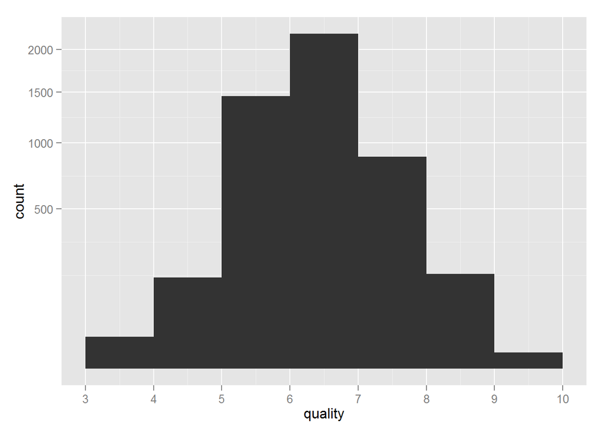

quality level of 6 to 7 has a highest number of wine. we can also observe that there is no alchol whose quality level is less than 3 and greater than 9.

Level of alcohol

```
##    Min. 1st Qu.  Median    Mean 3rd Qu.    Max.
##    8.00    9.50   10.40   10.51   11.40   14.20
```

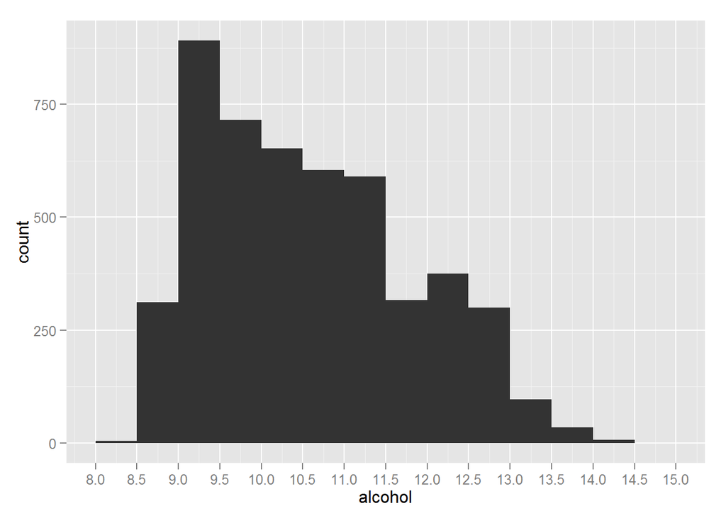

looks like Alcohol level based white wines skewed. mean is 10.51% and minum is 8%.based on the distribution window it looks like the highest number wines getting sold around 9.5% alcohol level.

Density of wine

```
##    Min. 1st Qu.  Median    Mean 3rd Qu.    Max.
##  0.9871  0.9917  0.9937  0.9940  0.9961  1.0390
```

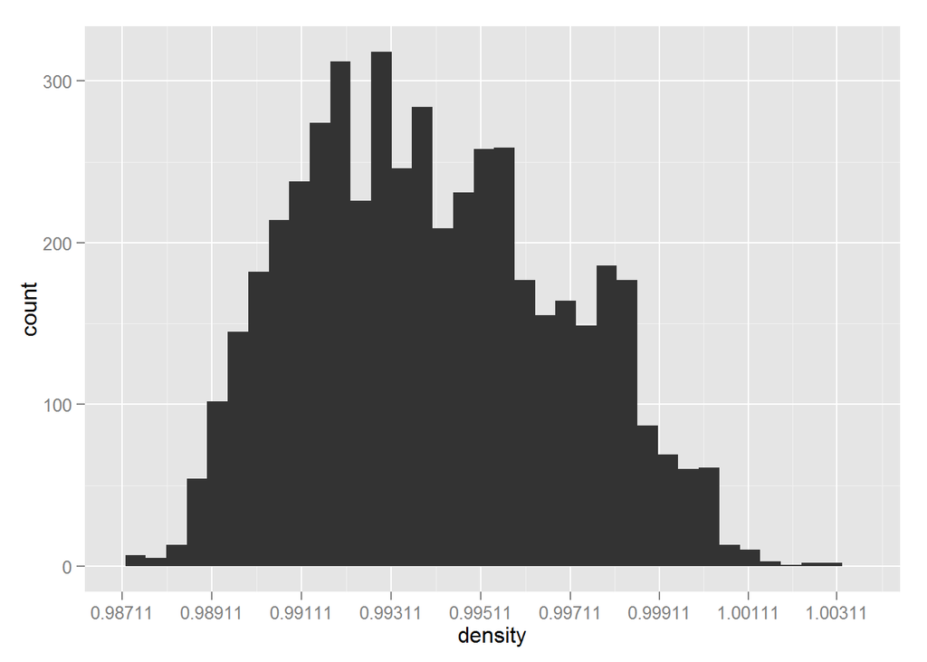

[output not shown]

density of 0.9940 peaks the count. we see the clear imapct of the density from the chart shown. the minum value for density in the taken data set is at .9871 and max value is at 1.0390.

Volatile Acidity impact :

```
##    Min. 1st Qu.  Median    Mean 3rd Qu.    Max.
##  0.0800  0.2100  0.2600  0.2782  0.3200  1.1000
```

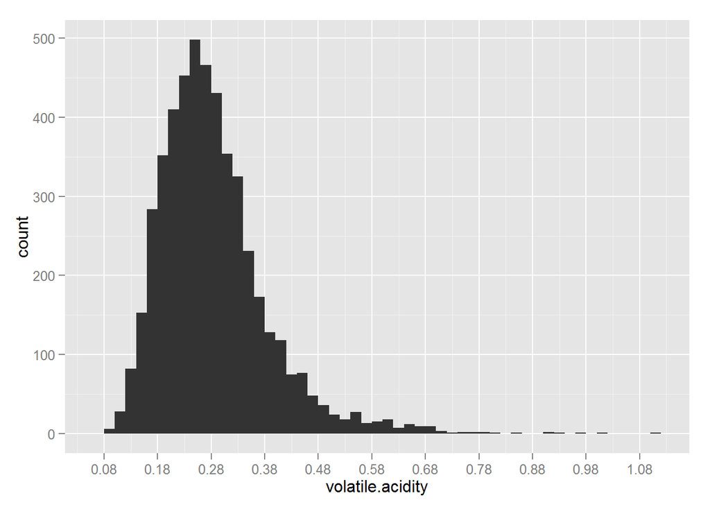

it looks like a normal distribution, also looks like the higher the acidity poor the taste will be. Acidity ranging from .08 to 1.1. .27 is the mean acidity value in the distribution.

Residual Sugar Analysis :

```
##    Min. 1st Qu.  Median    Mean 3rd Qu.    Max.
##   0.600   1.700   5.200   6.391   9.900  65.800
```

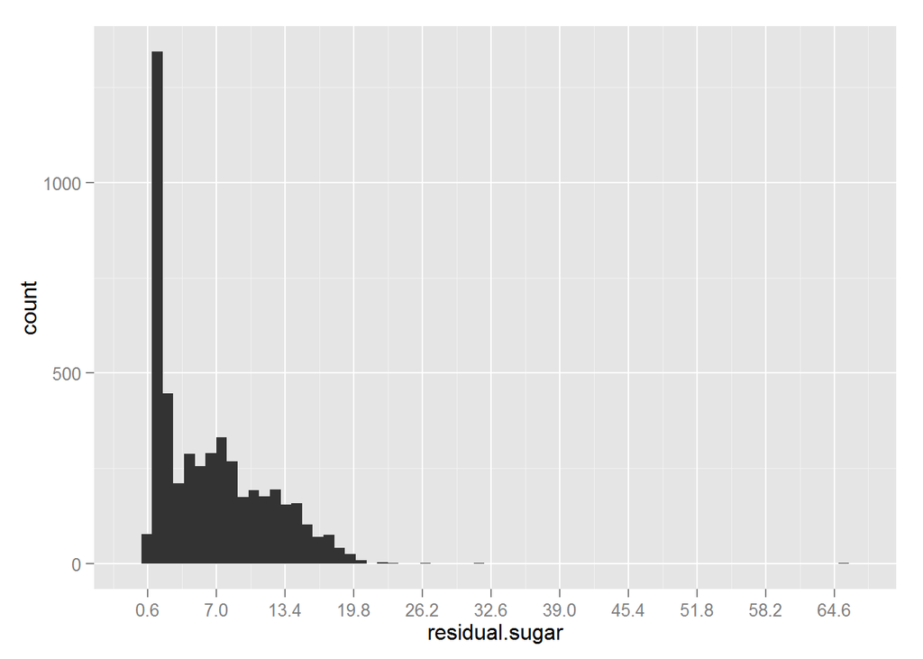

PH analysis :

```
##    Min. 1st Qu.  Median    Mean 3rd Qu.    Max.
##   2.720   3.090   3.180   3.188   3.280   3.820
```

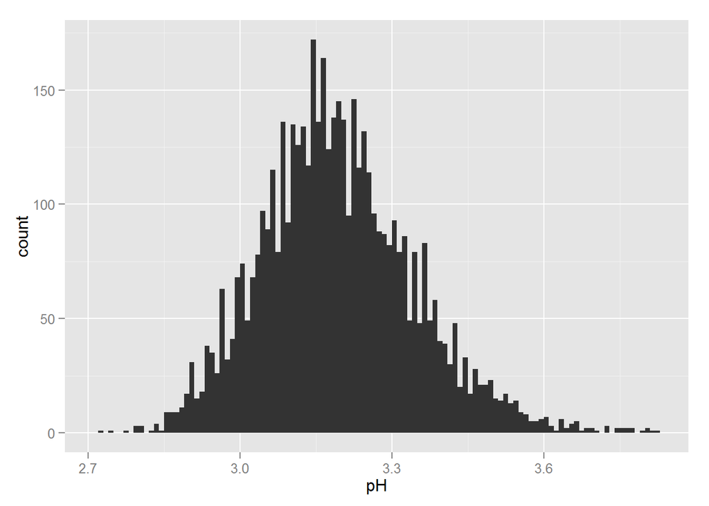

Level of Chlorides

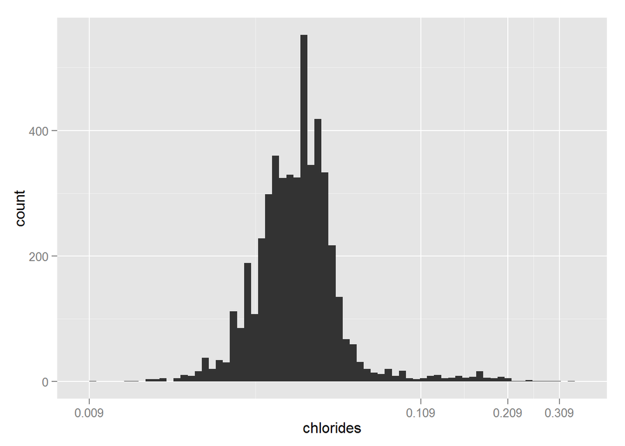

```
##    Min. 1st Qu.  Median    Mean 3rd Qu.    Max.
## 0.00900 0.03600 0.04300 0.04577 0.05000 0.34600
```

the plot was not that clear without log 10, tried with log 10. chlorides having as low as .009 to .34 in the wines we have for analysis. mean value is at .04577.

Multi variable analysis :

Quality vs Density:

```
## [1] -0.3071233
```

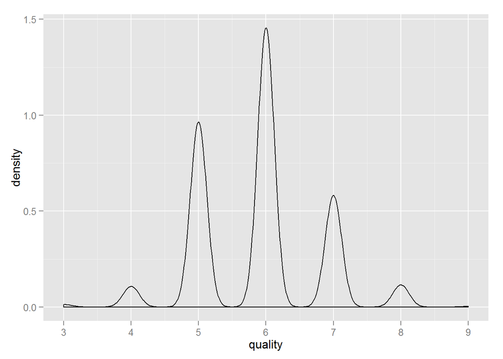

correlation of -.3 didnt give any clear picture so we went to create a plot to understand the data.

So far we have seen the parameters individually, lets see how the each parameter related with the other parameter. ggpair or ggcorr should give us the better plot picture.

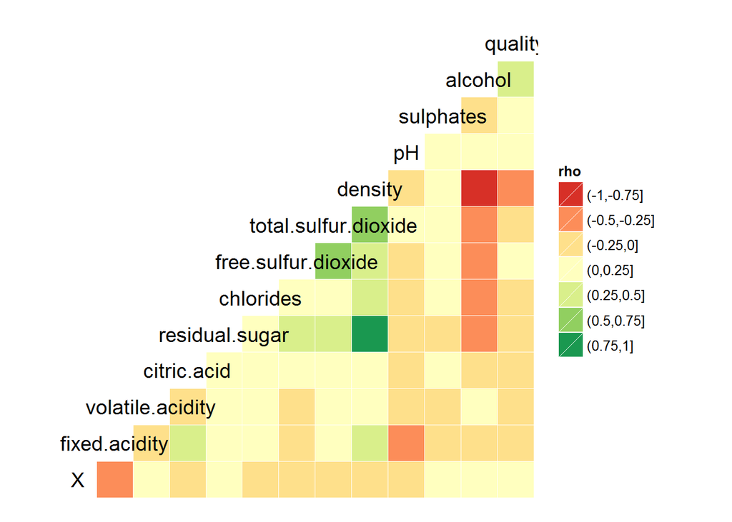

We can see some correlation in pairs like:

## Compare objective parameters of wines:

Relationship of density with alcohol.

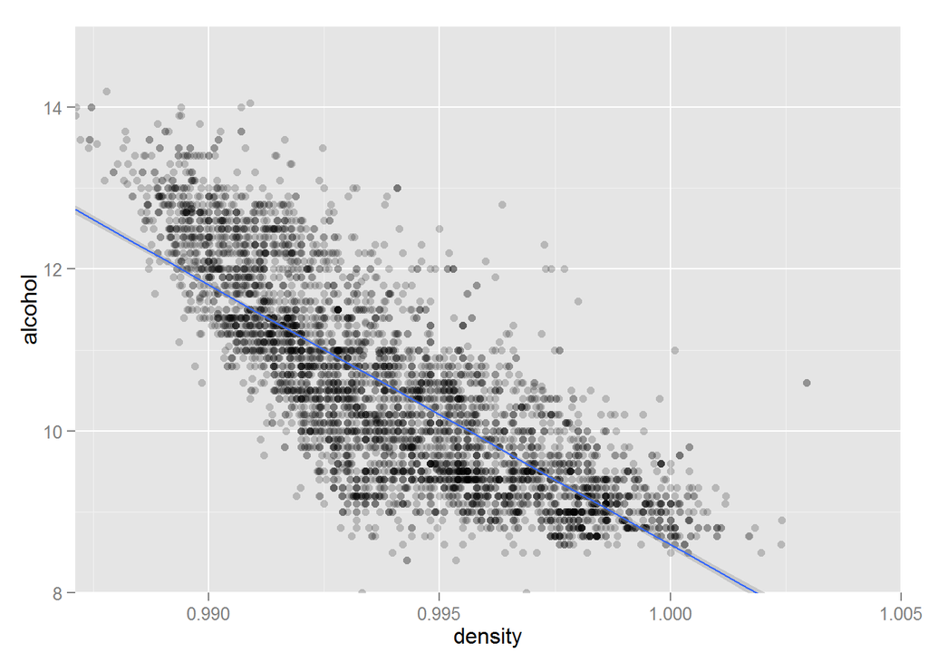

```
## [1] -0.7801376
```

density and alcohol are very much correlated, correlation values comes very close to .8 though its a negative correlated.

from the plot we could observe that the more or less the alcohol is inversaley proportional to the density. thought the alcohol level seems to be high at the density of .99 mostly the alcohol level getting dropped at the higher density wines.

## density vs. fixed.acidity plot

we have the correlation value of .265 between density and acidity , so it might be interesting to plot the graph and look at the trend.

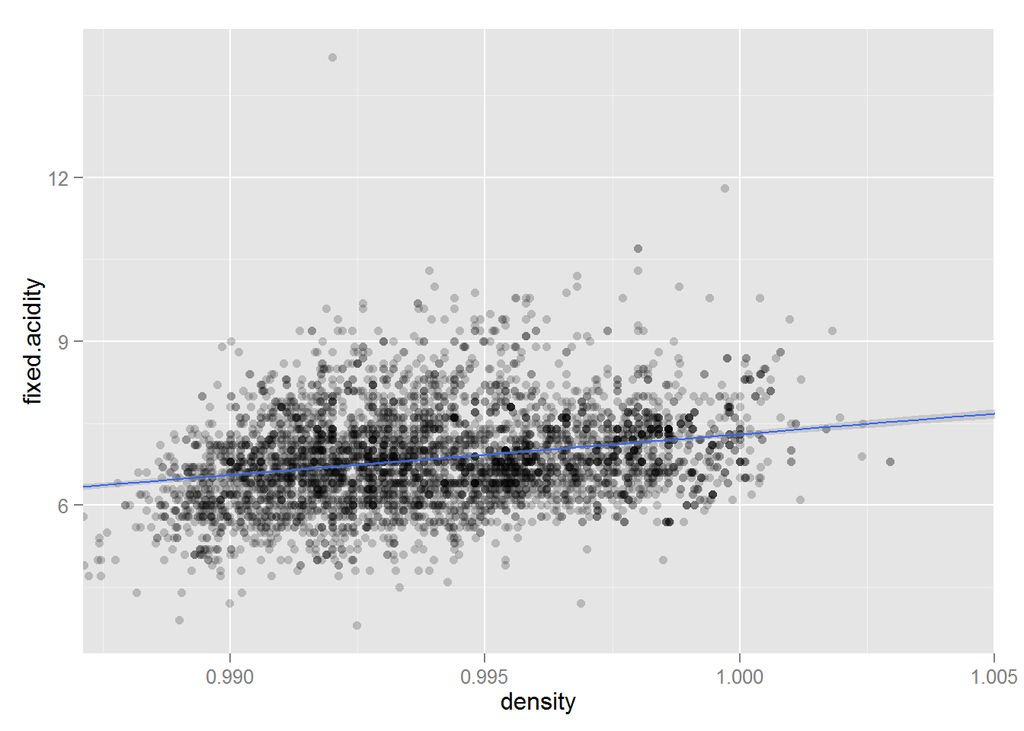

```
## [1] 0.265331
```

though in most of the cases the acidity level is not increasing for the higher density wines, we could observe that overall there is slight increase in acidity when the density increase.

## residual.sugar vs. density:

The residual sugar and density are mostly related, as they have a correlation value of .84.

```
## [1] 0.8389665
```

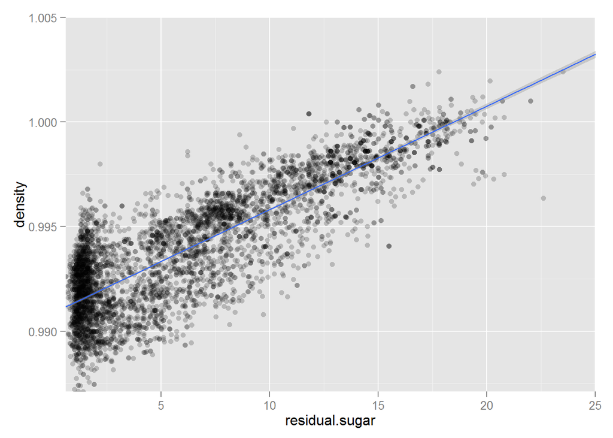

the graph gives very clear indication that the residual sugar very well correlated with the density. we could obhserver that of the wines we have for the analysis most of them having a residual sugar less than 10.

## Chlorides Vs density:

we could see slight correlation between chlorides vs density, plot might give us the better understing and closer look.

```
## [1] 0.2572113
```

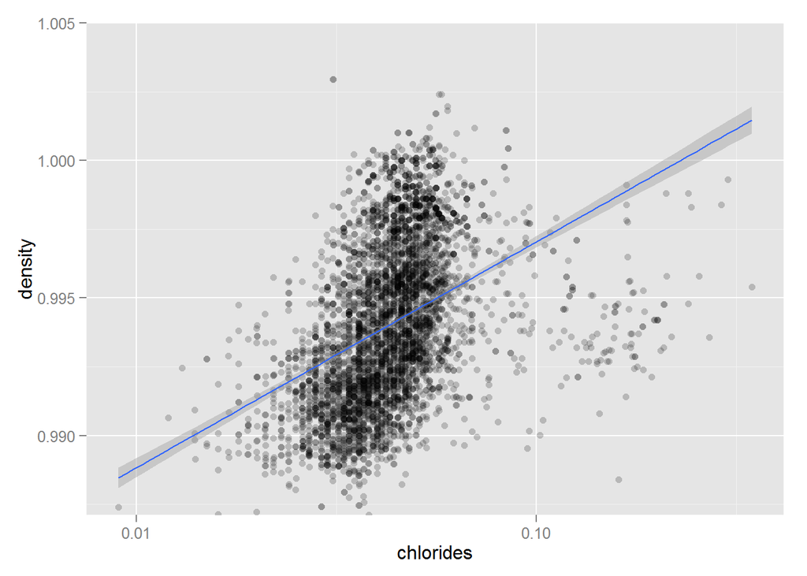

By looking at the scatter plot, i dont we get much of the insight about the chlorides, however over all from the cartesian axis it looks clear that the chlorides increses over slight increase of the density. or the other way density related with the chlorides is obvious.

## chlorides vs. sulphates

Dont see any relation ship between chlorides and sulphate. creating a plot to look at the trend.

```
## [1] 0.01676288
```

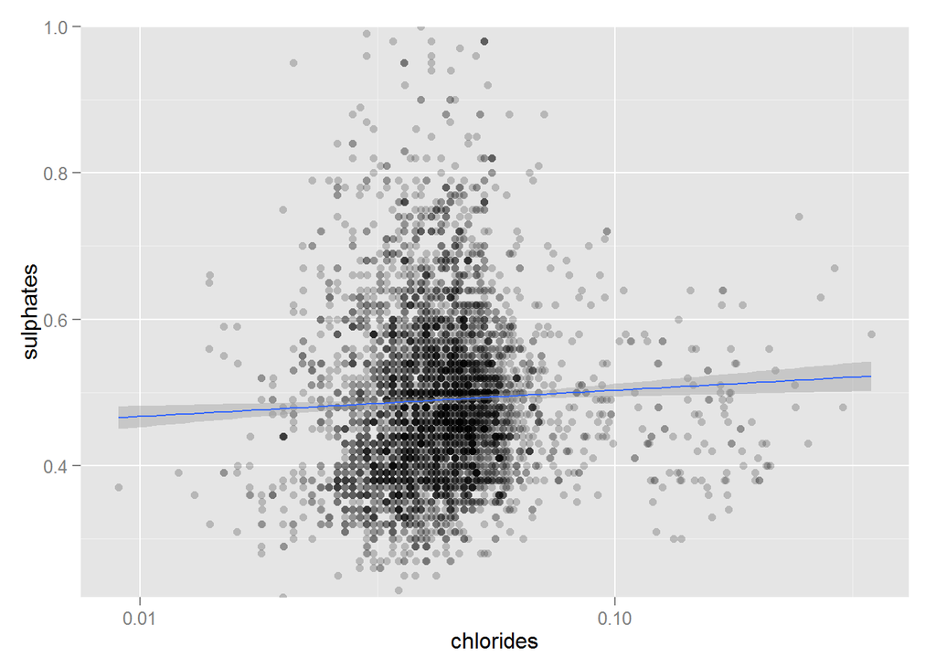

from the above plots it looks like the correlation varies significantly based on the variables and measure we use for analysis.

## Compare Quality vs. Alcohol

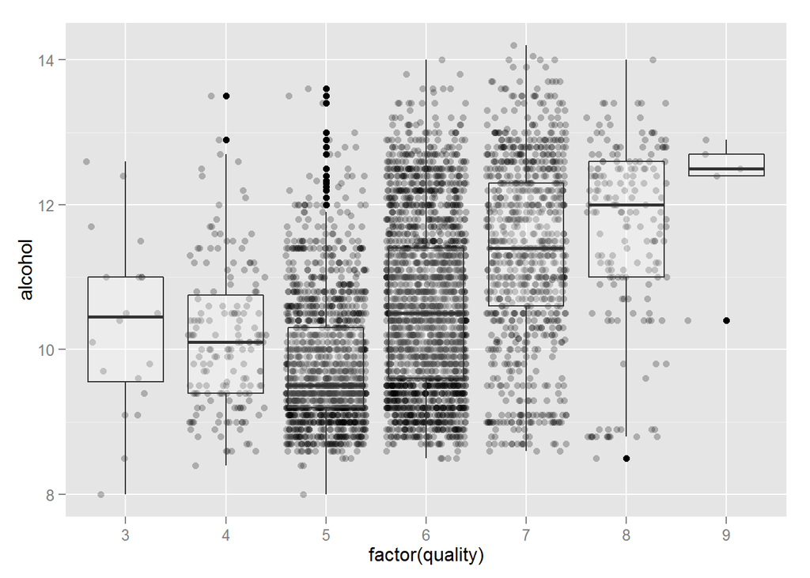

```
## [1] 0.4355747
```

may be acidity is not the right parameter to relate with the wine quality. alcohol goes hand in hand with quality of wine

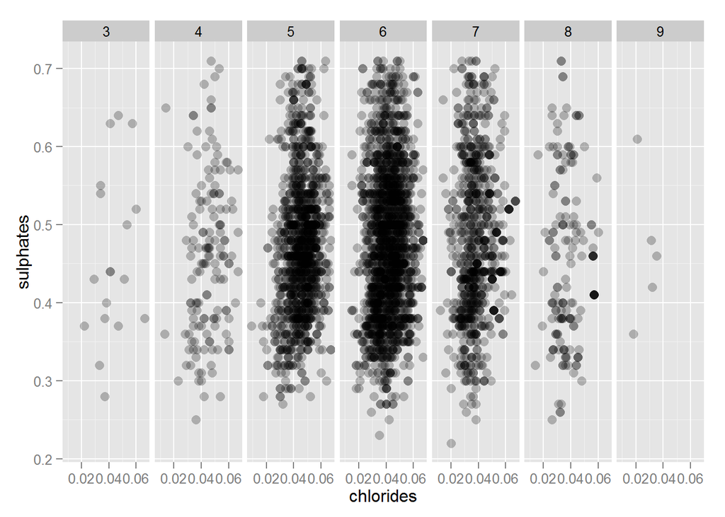

```
## [1] 0.01676288
```

## Fixed Acidity and Volatile Acidity

this is iteresting to compare as the fixed acidity and volatile acidity does not vary much.

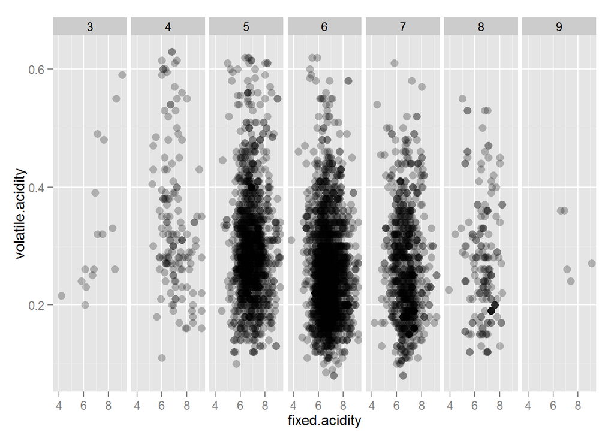

```
## [1] -0.02269729
```

samples of quality ‘6’ are highly concentrated around volatile acidity of 0.2 and fixed acidity of 6-7.

## Free Sulfur Dioxide and Total Sulfur Dioxide comparison :

correlation looks good between free sulfur and total sulfur dioxide. lets plot them in a graph and see closely.

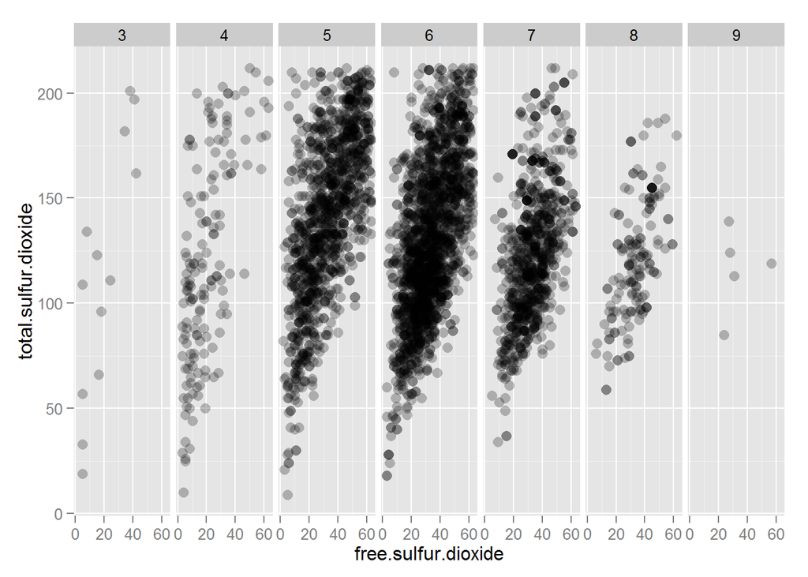

```
## [1] 0.615501
```

We can see clear positive correlation between total sulfur dioxide and free sulfur dioxide .

## PH and Alcohol

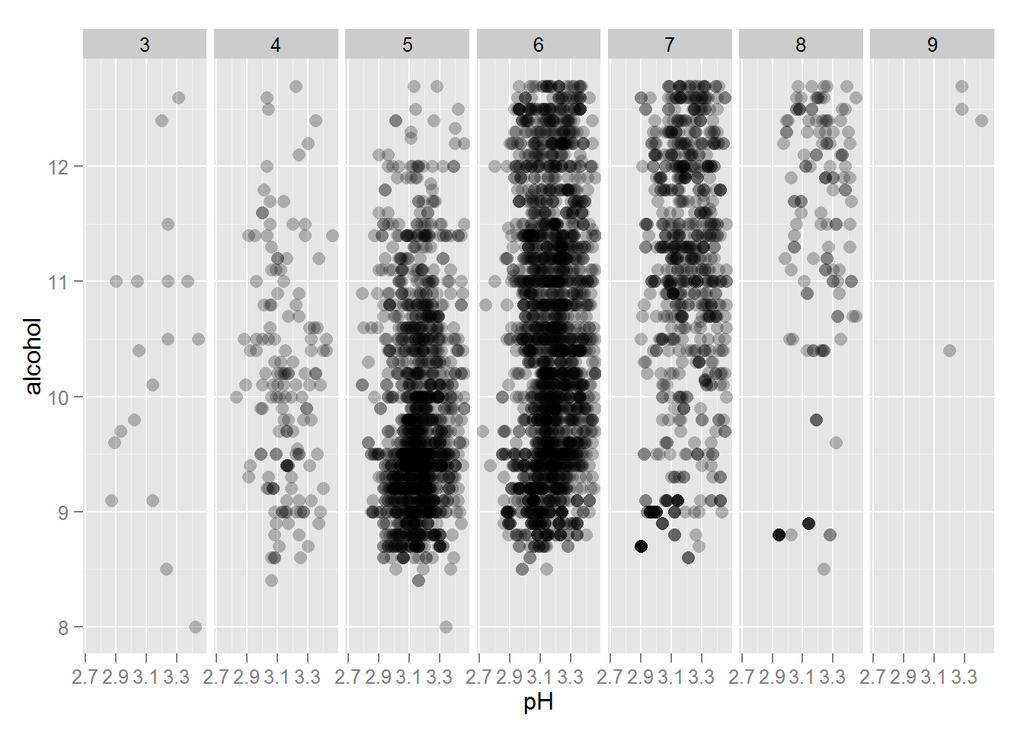

Citric Acid and Alcohol

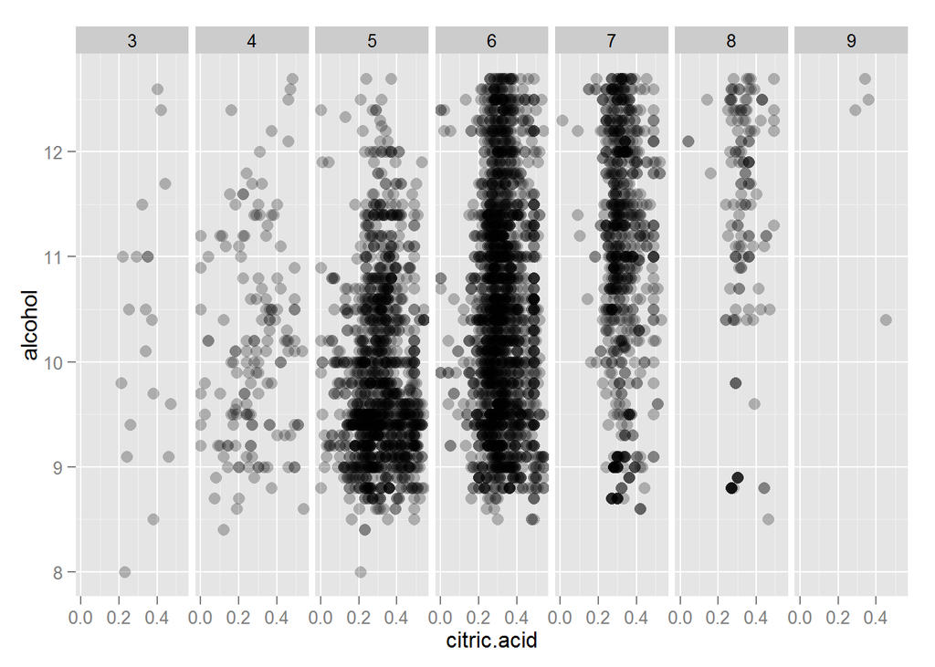

we can notice that most of the wine is clustered around where citric acid is 0.2 - 0.4.

## Final Plots and Summary

Plot One: Quality of Wine

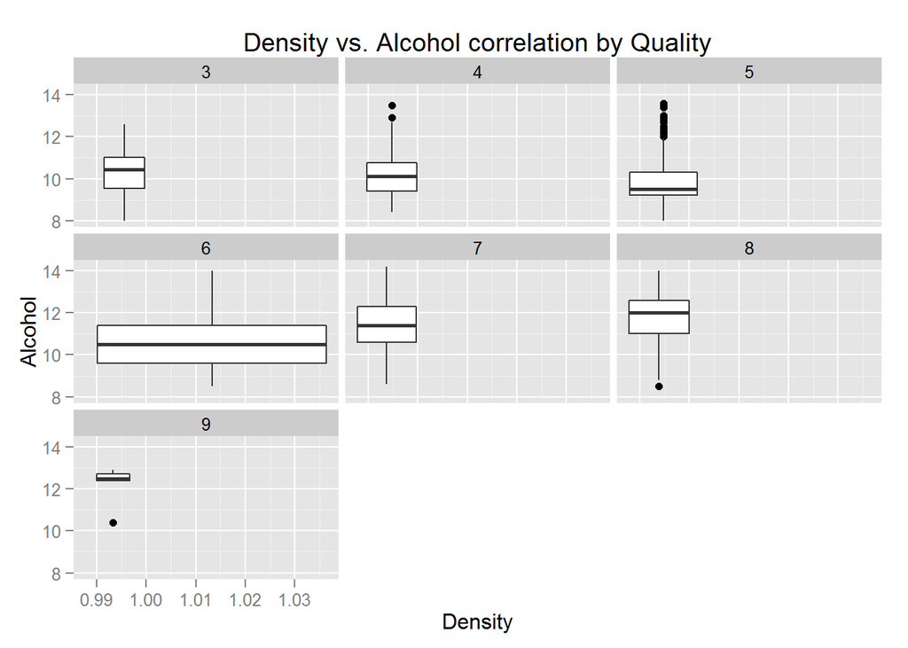

Quality vs. Alcohol

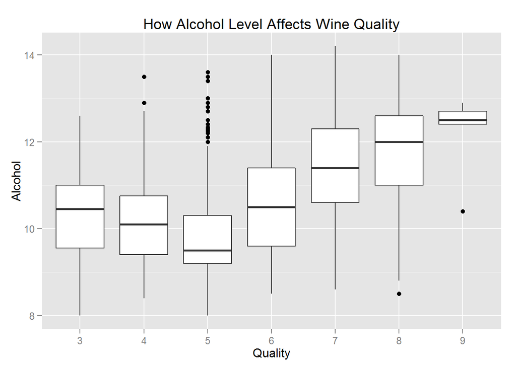

Description

Alcohol level and Quality have correlation value of 0.4. This is the strongest correlation we have found between an objective wine parameter and wine quality. 0.4 is not a high correlation level so we cannot use alcohol as a parameter for quality prediction.

it shows off clearly that the people like the wine better if we have higher alcohol level. however other parameters also giving closer impact.

## Reflection

i took white wine data from the suggested data with multiple reasons in mind to choose this data set. i never had a alcohol, never tested as well but through this exercise i want to challenge my self if i can work on something where i have no experience. Struggle : though looking at each parameter and observing its impact was interesting, but didnt give bigger picture or didnt help me to understand the parameters for famous wine. multi variate analysis and correlation across all other parameters gave me a better direction. i decided the parameters and variables once i got the correlation across the parameters and impact ful parameters.

i was trying to create the correlation map for different parameters using the ggpair but the picture didn’t come well though i used the small alpha value, then i switched it to ggcorr and picture looked better.

Ideas for improvement : For future exploration of this data I would pick one category of wine (for example, quality level 3-4, 5-7, 8-9) to look at the patterns which can appear in each of these three buckets. For advance analytics we can include how the other cold beverages performing compare to wine. Also, we can compare the color, what if we introduce a blue wine how the trend will be all that predictive analytics. may be we can add more parameter into consideration and bigger parameters will help us to narrow down the results.